# IE 582 - MERT ÇETİNKAYA - 2018702012 - HOMEWORK2

# Task 2

1. 256

2. 256

3. 3

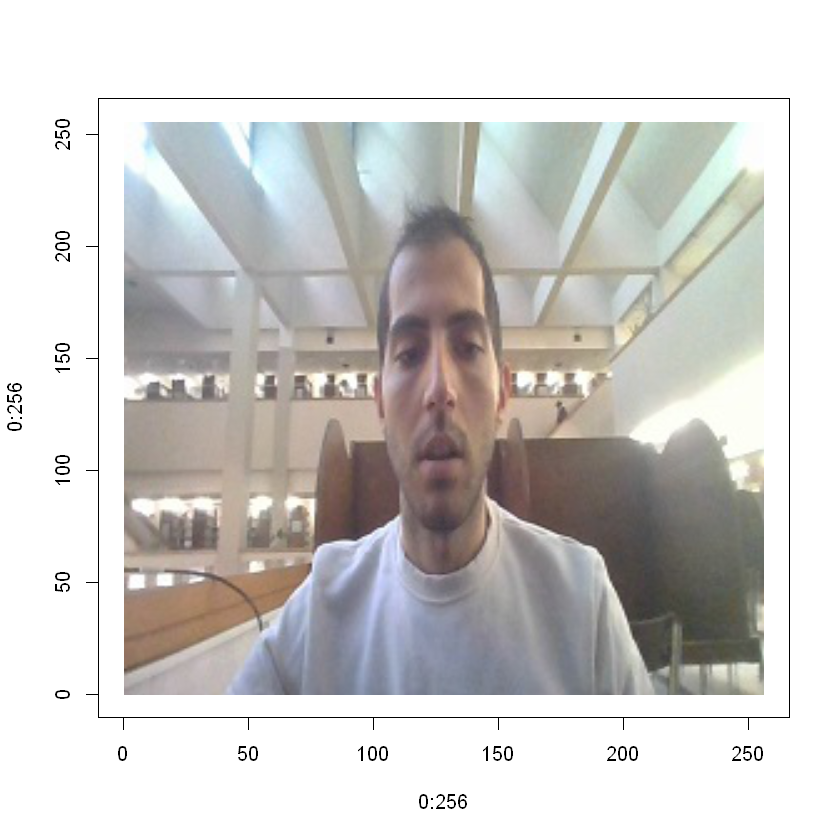

```r
#Let's read my photo, print its dimensions and print that photo.
library(jpeg)
photo=readJPEG("C:/Users/mertc/Desktop/boun/2019fall/data_mining/week5/hw2/data/mert_image.jpg")
dim(photo)
plot(0:256,0:256,type="n",axes=TRUE)
rasterImage(photo,0,0,256,256)
```

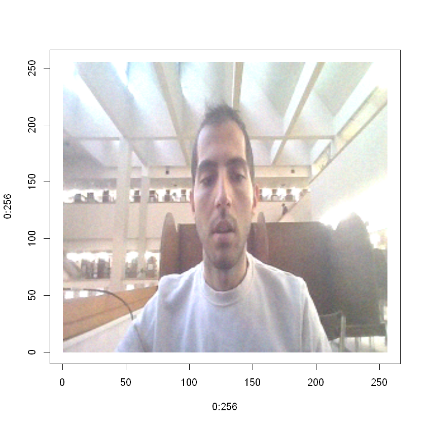

```r
#Let's produce our noisy photo and print it.
noisy_photo_red=photo[,,1]+runif(256*256,0.1*max(photo[,,1]),min(photo[,,1]))
noisy_photo_green=photo[,,2]+runif(256*256,0.1*max(photo[,,2]),min(photo[,,2]))
noisy_photo_blue=photo[,,3]+runif(256*256,0.1*max(photo[,,3]),min(photo[,,3]))
noisy_photo=photo
noisy_photo[,,1]=noisy_photo_red
noisy_photo[,,2]=noisy_photo_green
noisy_photo[,,3]=noisy_photo_blue
noisy_photo=ifelse(noisy_photo>1,1,noisy_photo)
plot(0:256,0:256,type="n",axes=TRUE)
rasterImage(noisy_photo,0,0,256,256)
```

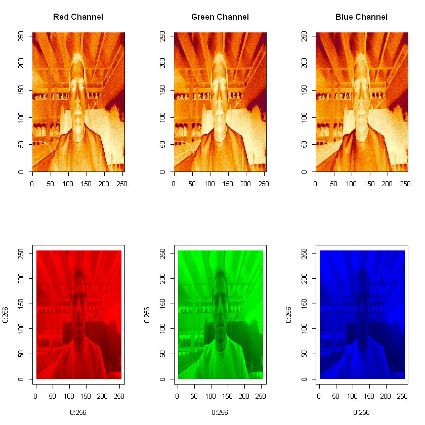

```r
#let's produce and print each channel of our noisy photo.
par(mfrow = c(2,3))
#We print the results of image function.
image(0:256,0:256,t(apply(noisy_photo_red,2,rev)),  axes = TRUE, main = "Red Channel" , xlab = "",ylab = "")
image(0:256,0:256,t(apply(noisy_photo_green,2,rev)),  axes = TRUE, main = "Green Channel" , xlab = "",ylab = "")
image(0:256,0:256,t(apply(noisy_photo_blue,2,rev)),   axes = TRUE, main = "Blue Channel", xlab = "",ylab = "" )
#We get each layer or channel and fill the others with 0 manually for each color and print the results.
noisy_photo[,,1]=noisy_photo_red
noisy_photo[,,2]=0
noisy_photo[,,3]=0
noisy_photo=ifelse(noisy_photo>1,1,noisy_photo)
plot(0:256,0:256,type="n",axes=TRUE)
rasterImage(noisy_photo,0,0,256,256)

noisy_photo[,,1]=0
noisy_photo[,,2]=noisy_photo_green
noisy_photo[,,3]=0
noisy_photo=ifelse(noisy_photo>1,1,noisy_photo)
plot(0:256,0:256,type="n",axes=TRUE)
rasterImage(noisy_photo,0,0,256,256)

noisy_photo[,,1]=0
noisy_photo[,,2]=0
noisy_photo[,,3]=noisy_photo_blue
noisy_photo=ifelse(noisy_photo>1,1,noisy_photo)
plot(0:256,0:256,type="n",axes=TRUE)
rasterImage(noisy_photo,0,0,256,256)
```

1. 256

2. 256

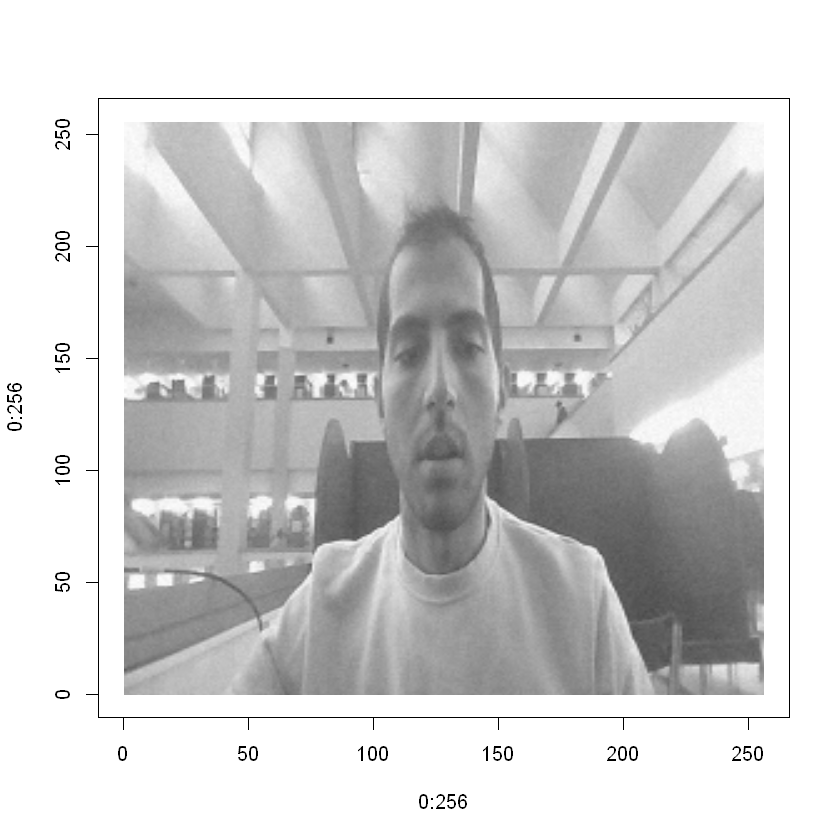

```r
#We transform our noisy image to a greyscale image. We also print dimension of this greyscale image and print this image.
noisy_photo_grey=(noisy_photo_red+noisy_photo_green+noisy_photo_blue)/max(noisy_photo_red+noisy_photo_green+noisy_photo_blue)
plot(0:256,0:256,type="n",axes=TRUE)
dim(noisy_photo_grey)
rasterImage(noisy_photo_grey,0,0,256,256)
```

```r
#We produce our patches matrix with right number of instances and features. We also fill it with the values of patches.
patches=matrix(0,232*232,25*25)
k=1
for (i in 1:232){
    for (j in 1:232){
        patches[k,]=as.vector(noisy_photo_grey[(i):(i+24),(j):(j+24)])
        k=k+1
    }
}
```

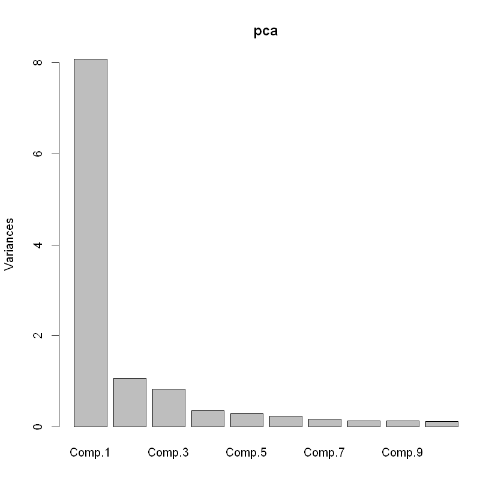

```r
#We apply pca on our patches matrix. We see that variance covered by first component is remarkably bigger than the others.
pca=princomp(patches)
plot(pca)
```

```r
#We see that approximately 60% of variance is covered by the first component. The second component covers approximately 8%
#of the variance and the third one covers approximately 6% of variance.
summary(pca)
```

```
Importance of components:
                          Comp.1     Comp.2     Comp.3     Comp.4     Comp.5
Standard deviation     2.8432607 1.03393104 0.90825731 0.59239871 0.53879225
Proportion of Variance 0.5976671 0.07903312 0.06098791 0.02594503 0.02146192
Cumulative Proportion  0.5976671 0.67670017 0.73768808 0.76363311 0.78509503
                           Comp.6     Comp.7      Comp.8      Comp.9    Comp.10
Standard deviation     0.48674242 0.41491165 0.365355182 0.361644685 0.34698197
Proportion of Variance 0.01751557 0.01272733 0.009868622 0.009669191 0.00890102
Cumulative Proportion  0.80261061 0.81533793 0.825206557 0.834875748 0.84377677
                           Comp.11     Comp.12     Comp.13    Comp.14
Standard deviation     0.319325257 0.317907811 0.292036932 0.27320688
Proportion of Variance 0.007538631 0.007471854 0.006305238 0.00551835
Cumulative Proportion  0.851315399 0.858787253 0.865092491 0.87061084
                           Comp.15     Comp.16     Comp.17     Comp.18
Standard deviation     0.250373060 0.248299309 0.233688462 0.230047079
Proportion of Variance 0.004634482 0.004558028 0.004037388 0.003912546
Cumulative Proportion  0.875245322 0.879803350 0.883840738 0.887753284
                           Comp.19     Comp.20     Comp.21     Comp.22
Standard deviation     0.226989256 0.209910966 0.196830035 0.185510397
Proportion of Variance 0.003809224 0.003257588 0.002864235 0.002544266
Cumulative Proportion  0.891562508 0.894820097 0.897684332 0.900228598
                         Comp.23     Comp.24     Comp.25     Comp.26
Standard deviation     0.1827570 0.178218498 0.173759790 0.170592309
Proportion of Variance 0.0024693 0.002348181 0.002232156 0.002151517
Cumulative Proportion  0.9026979 0.905046078 0.907278234 0.909429752
                           Comp.27    Comp.28     Comp.29    Comp.30
Standard deviation     0.169330311 0.16773265 0.154537802 0.15185669
Proportion of Variance 0.002119802 0.00207999 0.001765613 0.00170488
Cumulative Proportion  0.911549554 0.91362954 0.915395156 0.91710004
                           Comp.31     Comp.32     Comp.33     Comp.34
Standard deviation     0.149444746 0.145409890 0.141224141 0.134025816
Proportion of Variance 0.001651153 0.001563198 0.001474497 0.001328015
Cumulative Proportion  0.918751189 0.920314387 0.921788883 0.923116898
                           Comp.35     Comp.36     Comp.37     Comp.38
Standard deviation     0.133045160 0.127540316 0.126945892 0.125606700
Proportion of Variance 0.001308652 0.001202599 0.001191416 0.001166411
Cumulative Proportion  0.924425550 0.925628149 0.926819565 0.927985976
                           Comp.39     Comp.40     Comp.41     Comp.42
Standard deviation     0.125183850 0.124023319 0.117828905 0.116627636
Proportion of Variance 0.001158571 0.001137189 0.001026431 0.001005608
```

[output cut: 570 more lines]

```
Standard deviation     1.493629e-02 1.490975e-02 1.489984e-02 1.481680e-02
Proportion of Variance 1.649345e-05 1.643488e-05 1.641305e-05 1.623061e-05
Cumulative Proportion  9.997834e-01 9.997998e-01 9.998163e-01 9.998325e-01
                           Comp.615     Comp.616     Comp.617     Comp.618
Standard deviation     1.466109e-02 1.465342e-02 0.0146080524 1.457848e-02
Proportion of Variance 1.589128e-05 1.587464e-05 0.0000157765 1.571268e-05
Cumulative Proportion  9.998484e-01 9.998643e-01 0.9998800361 9.998957e-01
                           Comp.619     Comp.620     Comp.621     Comp.622
Standard deviation     1.450973e-02 1.440213e-02 1.431137e-02 1.424875e-02
Proportion of Variance 1.556485e-05 1.533484e-05 1.514218e-05 1.500995e-05
Cumulative Proportion  9.999113e-01 9.999266e-01 9.999418e-01 9.999568e-01
                           Comp.623     Comp.624     Comp.625
Standard deviation     1.421071e-02 1.383131e-02 1.382291e-02
Proportion of Variance 1.492992e-05 1.414336e-05 1.412618e-05
Cumulative Proportion  9.999717e-01 9.999859e-01 1.000000e+00
```

1. 232

2. 232

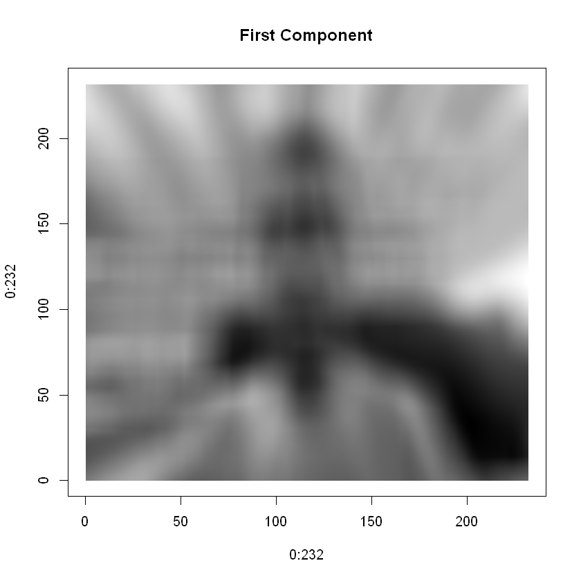

```r
#Let's normalise first score values and print them as an image. We also print the dimension.
normalised_scores_1=(pca$scores[,1] - min(pca$scores[,1]))/(max(pca$scores[,1]) - min(pca$scores[,1]))
dim(matrix(normalised_scores_1,232,232))
plot(0:232,0:232,type="n",axes=TRUE,main = "First Component")
rasterImage(t(matrix(normalised_scores_1,232,232)),0,0,232,232)
```

1. 232

2. 232

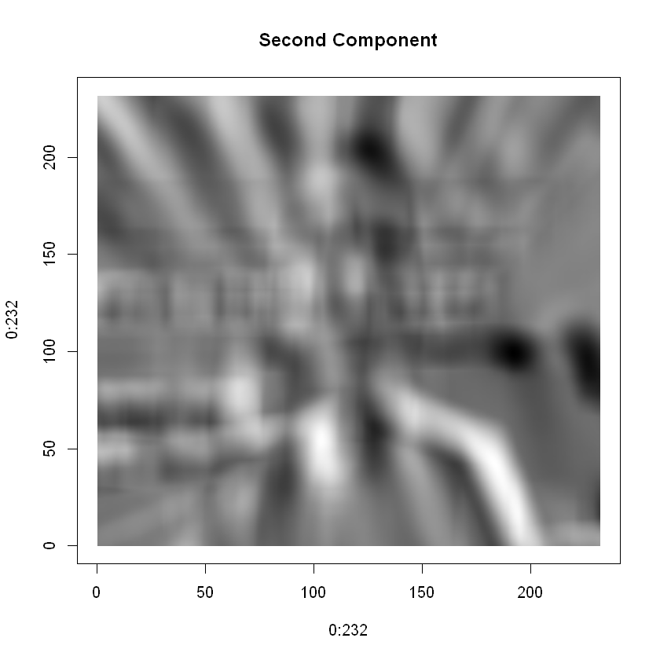

```r
#Let's normalise second score values and print them as an image. We also print the dimension.
normalised_scores_2=(pca$scores[,2] - min(pca$scores[,2]))/(max(pca$scores[,2]) - min(pca$scores[,2]))
dim(matrix(normalised_scores_2,232,232))
plot(0:232,0:232,type="n",axes=TRUE,main = "Second Component")
rasterImage(t(matrix(normalised_scores_2,232,232)),0,0,232,232)
```

1. 232

2. 232

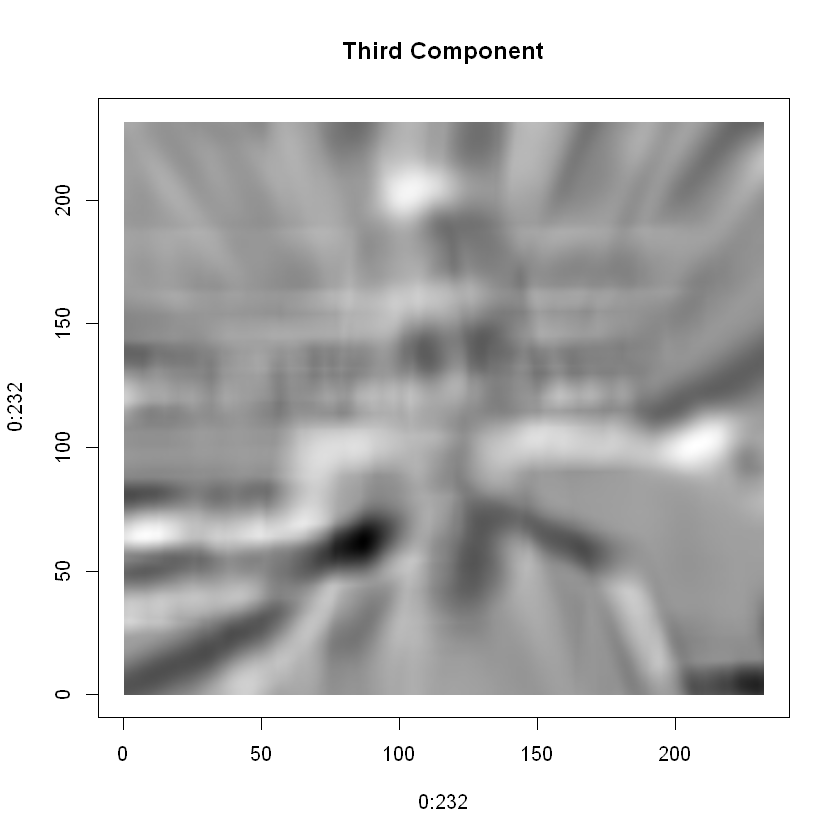

```r
#Let's normalise third score values and print them as an image. We also print the dimension.
normalised_scores_3=(pca$scores[,3] - min(pca$scores[,3]))/(max(pca$scores[,3]) - min(pca$scores[,3]))
dim(matrix(normalised_scores_3,232,232))
plot(0:232,0:232,type="n",axes=TRUE,main = "Third Component")
rasterImage(t(matrix(normalised_scores_3,232,232)),0,0,232,232)
```

We see that the first component gives more details than the second and the third component.

```r
#Let's print the dimension for the first three eigen vectors and print the first rows of them.
dim(pca$loadings[,1:3])
head(pca$loadings[,1:3])
```

1. 625

2. 3

| Comp.1 | Comp.2 | Comp.3 |
| --- | --- | --- |
| 0.03453890 | 0.01727998 | 0.05509948 |
| 0.03491442 | 0.01918186 | 0.05738059 |
| 0.03524868 | 0.02126726 | 0.05899557 |
| 0.03554222 | 0.02353544 | 0.05983246 |
| 0.03578167 | 0.02595745 | 0.05988342 |
| 0.03596884 | 0.02853450 | 0.05907588 |

1. 25

2. 25

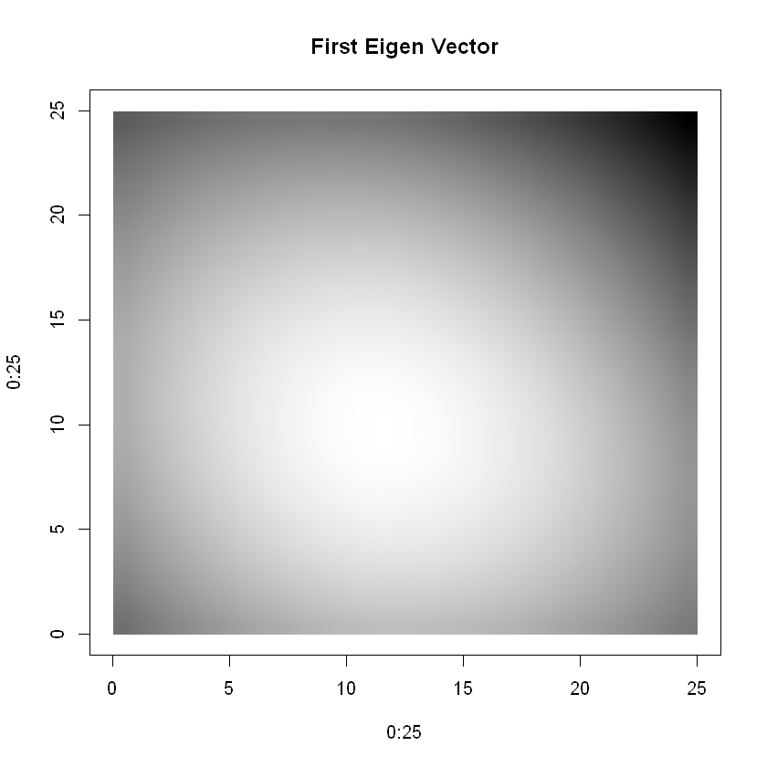

```r
#Let's normalise first eigen vectors and print it as an image. We also print the dimension.
normalised_loadings_1=(pca$loadings[,1] - min(pca$loadings[,1]))/(max(pca$loadings[,1]) - min(pca$loadings[,1]))
dim(matrix(normalised_loadings_1,25,25))
plot(0:25,0:25,type="n",axes=TRUE,main = "First Eigen Vector")
rasterImage(t(matrix(normalised_loadings_1,25,25)),0,0,25,25)
```

1. 25

2. 25

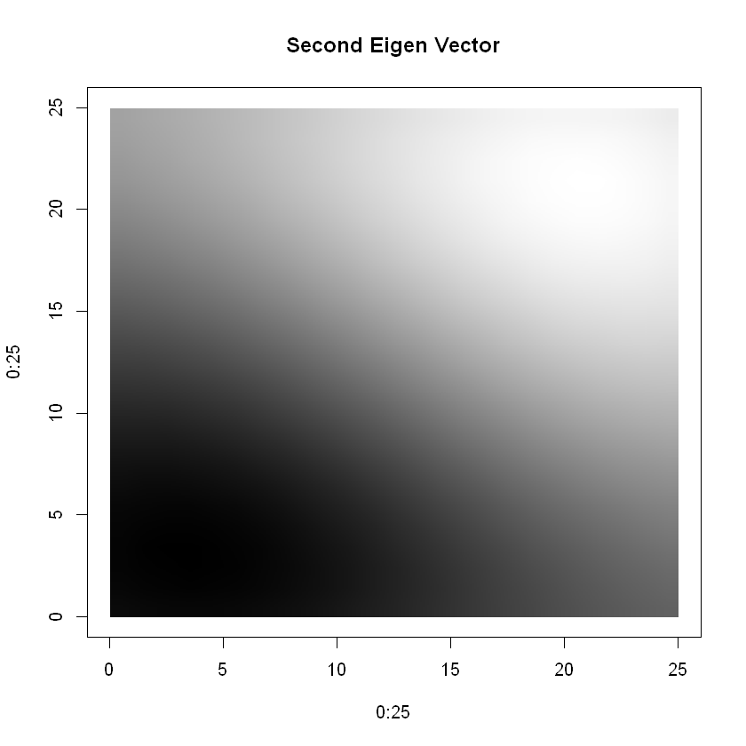

```r
#Let's normalise second eigen vector and print it as an image. We also print the dimension.
normalised_loadings_2=(pca$loadings[,2] - min(pca$loadings[,2]))/(max(pca$loadings[,2]) - min(pca$loadings[,2]))
dim(matrix(normalised_loadings_2,25,25))
plot(0:25,0:25,type="n",axes=TRUE,main = "Second Eigen Vector")
rasterImage(t(matrix(normalised_loadings_2,25,25)),0,0,25,25)
```

1. 25

2. 25

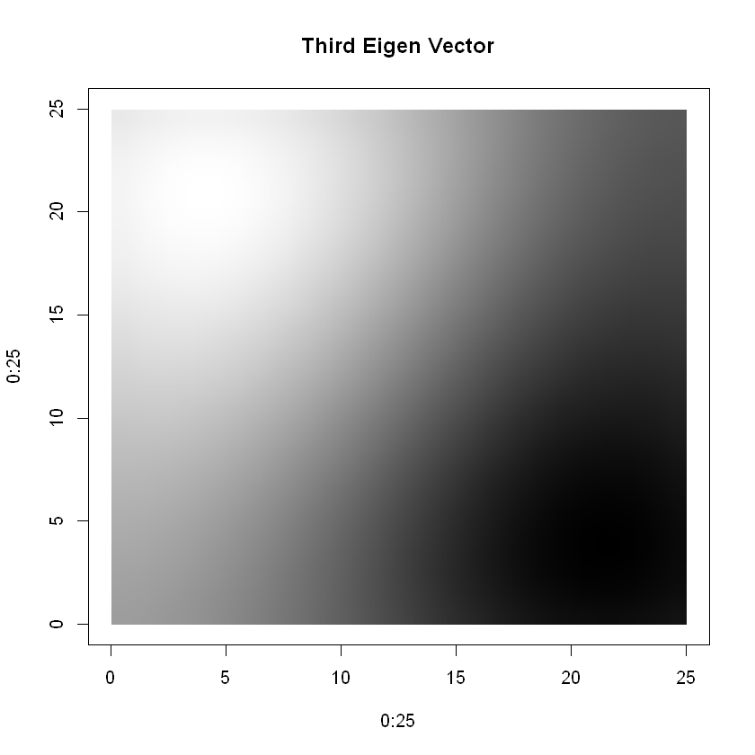

```r
#Let's normalise third eigen vector and print it as an image. We also print the dimension.
normalised_loadings_3=(pca$loadings[,3] - min(pca$loadings[,3]))/(max(pca$loadings[,3]) - min(pca$loadings[,3]))
dim(matrix(normalised_loadings_3,25,25))
plot(0:25,0:25,type="n",axes=TRUE,main = "Third Eigen Vector")
rasterImage(t(matrix(normalised_loadings_3,25,25)),0,0,25,25)
```

The pixels in the first eigen vector are more homogeneous and there is a cleaner view. However, the dark areas in the second and in the third eigenvectors are bigger and there is a more heterogeneous view. We can think that this situation causes a more uncertain and non clean view that we see in the second and in the third component.